# Visualizing genomic data

There are (at least) two types of data visualization:

- exploratory: raw, unpolished plots as part of data analysis and exploration
- publication-ready: informative, clear, and visually attractive illustrations of results for showing to others

Both of these types of visualizations can be made with R. In fact, R offers multiple graphics systems. This is because R is extensible, and because progress in R graphics over the years has proceeded largely not by replacing the old functions, but by adding packages. Each of the different graphics systems has its advantages and limitations.

In this section, we introduce two of them. First, we have a cursory look at the base R plotting functions for data exploration. They live in the `graphics` package, which ships with every R installation. Subsequently, we introduce the `ggplot2` package for publication-ready high quality graphics in R.

## Base R graphics

Base R graphics came historically first: simple, procedural, conceptually motivated by drawing on a canvas. There are specialized functions for different types of plots such as `barplot`, `boxplot`, and `hist`. The base R plotting functions are great for quick interactive data exploration.

The most basic function is `plot`. In the code below, we use it to plot data from an enzyme-linked immunosorbent assay (ELISA) assay. The assay was used to quantify the activity of the enzyme deoxyribonuclease (DNase), which degrades DNA. The data is available as an R data object `DNase`, which comes with base R. The object `DNase` is a `data.frame` whose columns are `Run`, the assay run; `conc`, the protein concentration that was used; and `density`, the measured optical density.

```r
data(DNase)
head(DNase)
```

```
##   Run  conc density
## 1   1 0.049   0.017
## 2   1 0.049   0.018
## 3   1 0.195   0.121
## 4   1 0.195   0.124
## 5   1 0.391   0.206
## 6   1 0.391   0.215
```

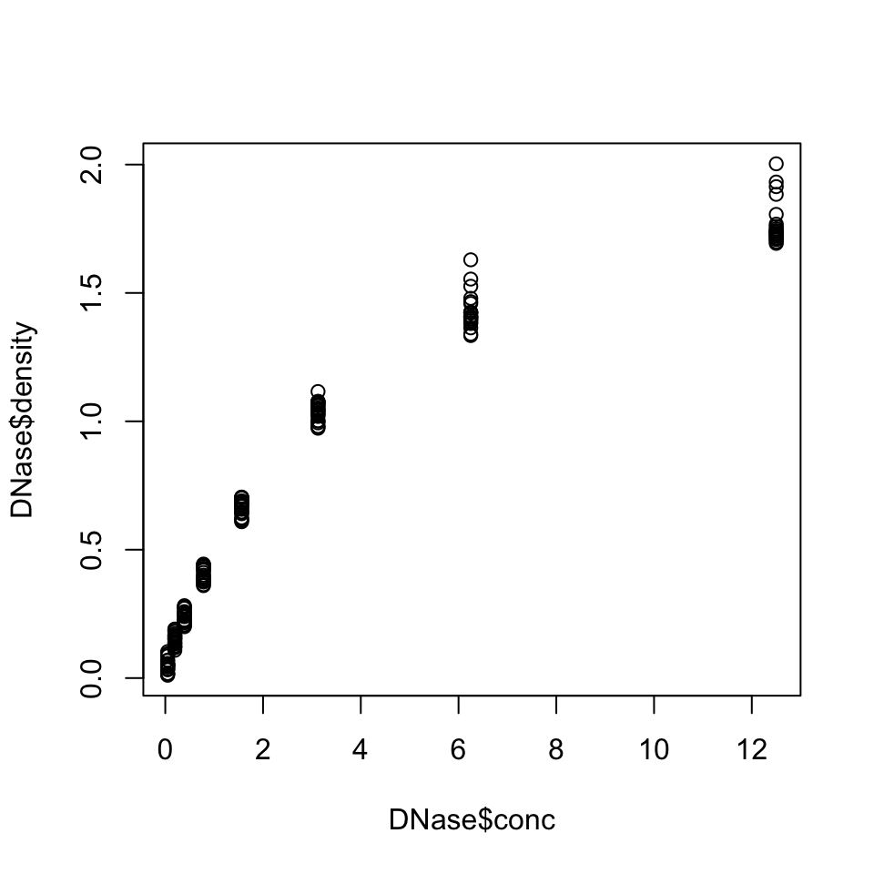

```r
plot(x=DNase$conc, y=DNase$density)
```

This basic plot can be customized, for example by changing the plot symbol and axis labels using the parameters `xlab`, `ylab` and `pch` (plot character). Information about the variables is stored in the object `DNase`, and we can access it with the `attr` function.

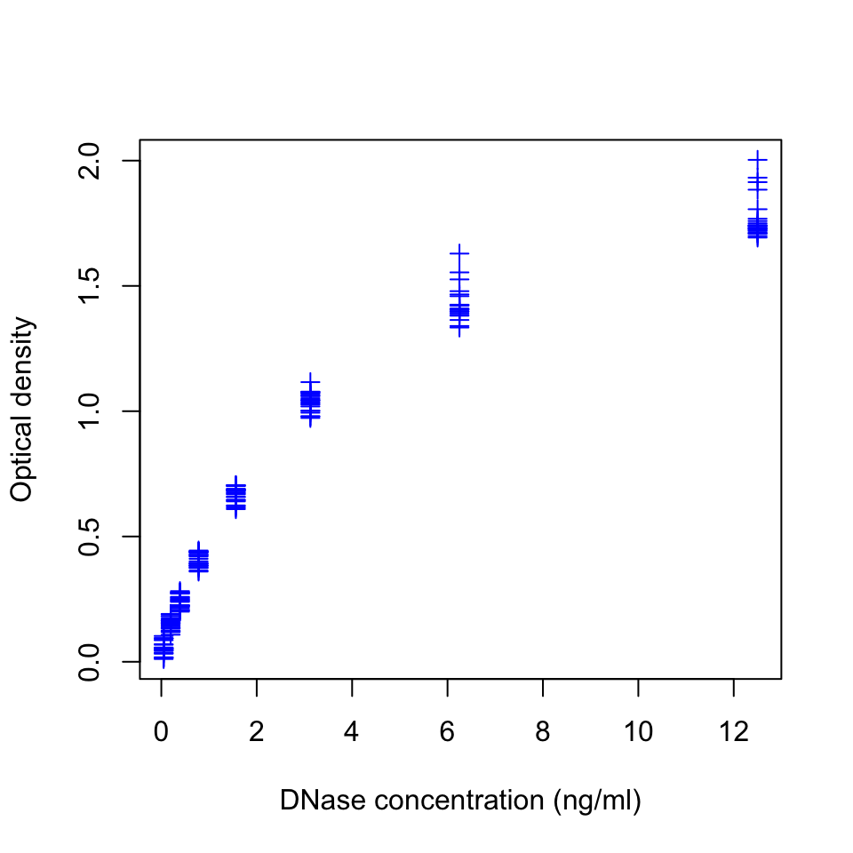

```r
plot(DNase$conc, DNase$density,
  ylab = attr(DNase, "labels")$y,
  xlab = paste(attr(DNase, "labels")$x, attr(DNase, "units")$x),
  pch = 3,
  col = "blue")
```

Besides scatterplots, there are additional built-in functions functions for typical exploratory data visualizations such as histograms and boxplots.

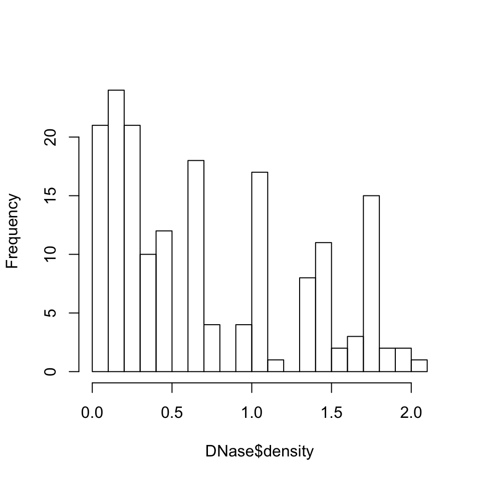

```r
hist(DNase$density, breaks=25, main = "")
```

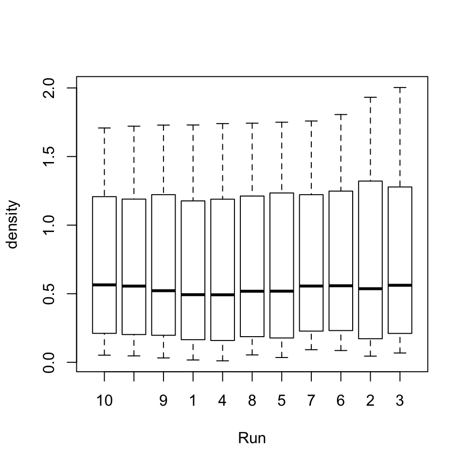

```r
boxplot(density ~ Run, data = DNase)
```

Boxplots are convenient for showing multiple distributions next to each other in a compact space.

## ggplot2

[ggplot2](https://ggplot2.tidyverse.org) is a package by Hadley Wickham that implements the idea of grammar of graphics – a concept created by Leland Wilkinson in his eponymous [book](https://www.springer.com/gp/book/9780387245447).

When compared to the concept of base R plotting, this is a more high-level approach: in the grammar of graphics, graphics are built up from modular logical pieces, so that we can easily try different visualization types for our data like switching in and out parts of a sentence in human language. There is no concept of a canvas or a plotter, rather, the user gives `ggplot2` a high-level description of the desired plot, in the form of an R object, and the rendering engine lays out the graphics and renders them on the output device.

Let’s start by loading the package and redoing the simple scatterplot for the DNase experiment.

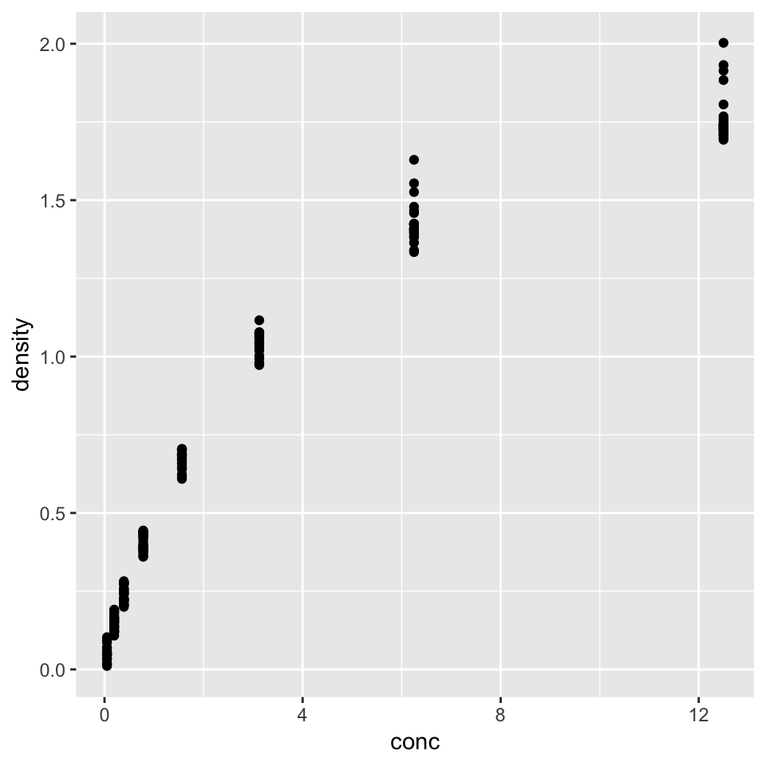

```r
library("ggplot2")
ggplot(DNase, aes(x = conc, y = density)) + geom_point()
```

We just wrote our first “sentence” using the grammar of graphics. Let’s deconstruct this sentence. First, we specified the data frame that contains the data, `DNase`. The `aes` (this stands for *aesthetic*) argument states which variables we want to see mapped to the *x*- and *y*-axes, respectively. Finally, we stated that we want the plot to use points (as opposed to, say, lines or bars), by adding the result of calling the function `geom_point`.

We continue working with a gene expression microarray dataset that reports the gene expression of around 100 individual cells from mouse embryos at different time points in early development ([Ohnishi et al., 2014](https://www.ncbi.nlm.nih.gov/pubmed/24292013)).

We load the data from the Bioconductor experimental data package Hiiragi2013.

```r
library(Biobase)
library(Hiiragi2013)

data(x)
eset <- x
eset
```

```
## ExpressionSet (storageMode: lockedEnvironment)
## assayData: 45101 features, 101 samples
##   element names: exprs
## protocolData
##   sampleNames: 1 E3.25 2 E3.25 ... 101 E4.5 (FGF4-KO) (101 total)
##   varLabels: ScanDate
##   varMetadata: labelDescription
## phenoData
##   sampleNames: 1 E3.25 2 E3.25 ... 101 E4.5 (FGF4-KO) (101 total)
##   varLabels: File.name Embryonic.day ... sampleColour (8 total)
##   varMetadata: labelDescription
## featureData
##   featureNames: 1415670_at 1415671_at ... AFFX-TrpnX-M_at (45101
##     total)
##   fvarLabels: symbol genename ensembl
##   fvarMetadata: labelDescription
## experimentData: use 'experimentData(object)'
## Annotation: mouse4302
```

The 101 columns of the `ExpressionSet` correspond to the samples (each of these is a single cell), the 45,101 rows correspond to the genes probed by the array, an [Affymetrix mouse4302 array](http://www.affymetrix.com/support/technical/byproduct.affx?product=moe430-20).

Let’s have a look at what information is available about the samples.

```r
head(pData(eset), n = 2)
```

```
##         File.name Embryonic.day Total.number.of.cells lineage genotype
## 1 E3.25  1_C32_IN         E3.25                    32               WT
## 2 E3.25  2_C32_IN         E3.25                    32               WT
##           ScanDate sampleGroup sampleColour
## 1 E3.25 2011-03-16       E3.25      #CAB2D6
## 2 E3.25 2011-03-16       E3.25      #CAB2D6
```

The information provided is a mix of information about the cells (i.e., age, size and genotype of the embryo from which they were obtained) and technical information (scan date, raw data file name). By convention, time in the development of the mouse embryo is measured in days, and reported as, for instance, `E3.5`. Moreover, in the paper the authors divided the cells into 8 biological groups (`sampleGroup`), based on age, genotype and lineage, and they defined a color scheme to represent these groups.

We define a small `data.frame` that contains summary information for each group: the number of cells and the preferred color.

```r
grtab <- table(pData(eset)$sampleGroup)
spl <- split(pData(eset)$sampleColour, pData(eset)$sampleGroup)
grcol <- sapply(spl, function(x) x[1])
groups <- data.frame(sampleGroup = names(grtab),
                    n = as.integer(grtab),
                    color = grcol,
                    stringsAsFactors=FALSE)
groups
```

```
##                     sampleGroup  n   color
## E3.25                     E3.25 36 #CAB2D6
## E3.25 (FGF4-KO) E3.25 (FGF4-KO) 17 #FDBF6F
## E3.5 (EPI)           E3.5 (EPI) 11 #A6CEE3
## E3.5 (FGF4-KO)   E3.5 (FGF4-KO)  8 #FF7F00
## E3.5 (PE)             E3.5 (PE) 11 #B2DF8A
## E4.5 (EPI)           E4.5 (EPI)  4 #1F78B4
## E4.5 (FGF4-KO)   E4.5 (FGF4-KO) 10 #E31A1C
## E4.5 (PE)             E4.5 (PE)  4 #33A02C
```

We plot the number of cells for each of the 8 groups using `ggplot`.

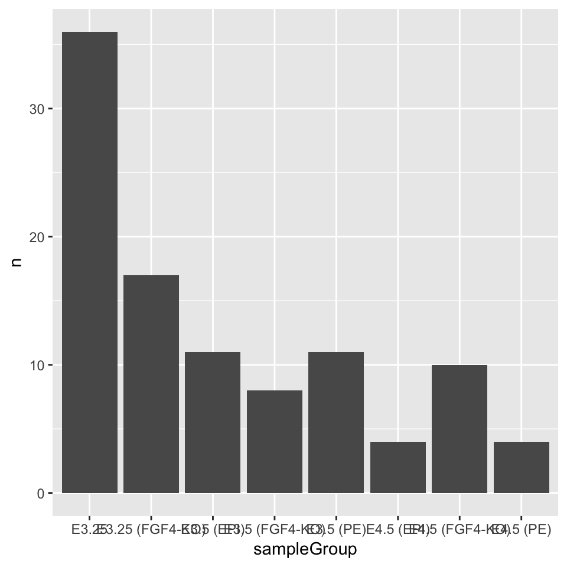

```r
ggplot(groups, aes(x = sampleGroup, y = n)) +
  geom_bar(stat = "identity")
```

With `geom_bar` we now told ggplot that we want each data item (each row of groups) to be represented by a bar. Bars are one example of geometric object (`geom` in the `ggplot2` package’s parlance) that `ggplot` knows about. We have already seen another such object: points, indicated by the `geom_point` function.

We provided the argument `stat = "identity"` (in other words, do nothing) to the `geom_bar` function, since otherwise it would try to compute a histogram of the data (the default value of stat is `"count"`). `stat` is short for *statistic*, which is what we call any function of data. Besides the identity and count statistic, there are others, such as smoothing, averaging, binning, or other operations that reduce the data in some way.

These concepts -– data, geometrical objects, statistics -– are some of the ingredients of the grammar of graphics, just as nouns, verbs and adverbs are ingredients of an English sentence.

To improve the barplot, we use color for the bars to indicate which bar corresponds to which group. For better readability of the bar labels, we rotate them by 45 degrees.

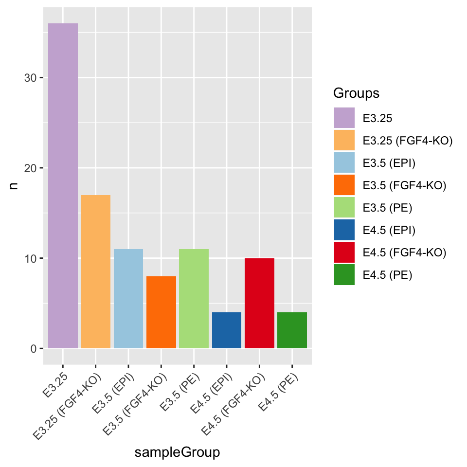

```r
ggplot(groups, aes(x = sampleGroup, y = n, fill = sampleGroup)) +
  geom_bar(stat = "identity") +
  scale_fill_manual(values = grcol, name = "Groups") +
  theme(axis.text.x = element_text(angle = 45, hjust=1))
```